[figure not shown]

### Bayesian Modeling for Socio-Environmental Data

#### June 01, 2016

#### Table of Contents

I. Motivation

II. Problem

III. Premliminaries

IV. Pooled model

V. Intercepts vary with carbon level in site soils and slopes vary with fertilizer type

VI. Slope *and* intercepts vary by site

#### I. Motivation

Multi-level models are a workhorse for understanding ecological processes because so many problems contain information at nested spatial scales, levels of organization, or categories. This problem will give you practice implementing the math that you wrote down in the model building exercise on N<sub>2</sub>O emissions from agricultural soils. The deterministic models that we will use here are linear, but the approach applies equally well to non-linear forms. The data set that you will analyze is described in the companion document `Multi-level model exercise.pdf`.

#### II. Problem

You will write JAGS code to implement models of increasing complexity and power.

#### III. Premliminaries

You need to load some data and libraries. It is always a good idea to look at the data. Note that the columns `group.index` and `fert.index` contain indices for sites and fertilizer types.

```r
library(rjags)
```

```r
library(reshape)
library(ggplot2)
set.seed(5)
y=read.csv("NO_2 emission all data for exercise.csv")
w=read.csv("Site_level_carbon_data for exercise.csv")
w$mean=w$mean/100  #transform % to proportion
y=y[,2:9]
y.n.sites = length(unique(y$group))
head(y)
```

```
##   fertilizer group carbon n.input emission reps group.index fert.index
## 1          A    14    2.7     180    0.620   13          10          2
## 2          A    14    4.6     180    0.450   13          10          2
## 3          A    11    0.9     112    0.230   12           7          2
## 4          A    38    0.5     100    0.153   14          29          2
## 5          A     1    4.0     250    1.000    6           1          2
## 6          A    38    0.5     100    0.216   14          29          2
```

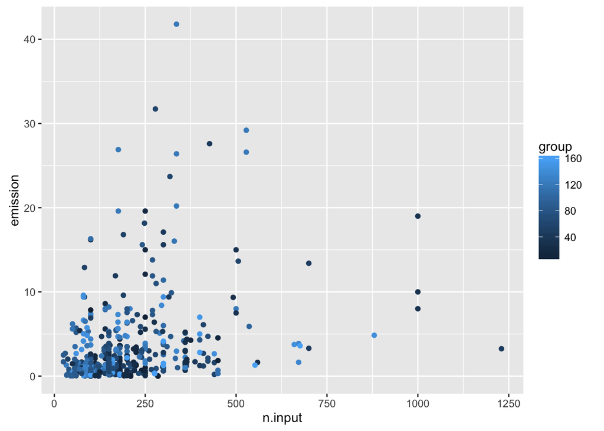

```r
qplot(n.input, emission, data=y, color =  group)
```

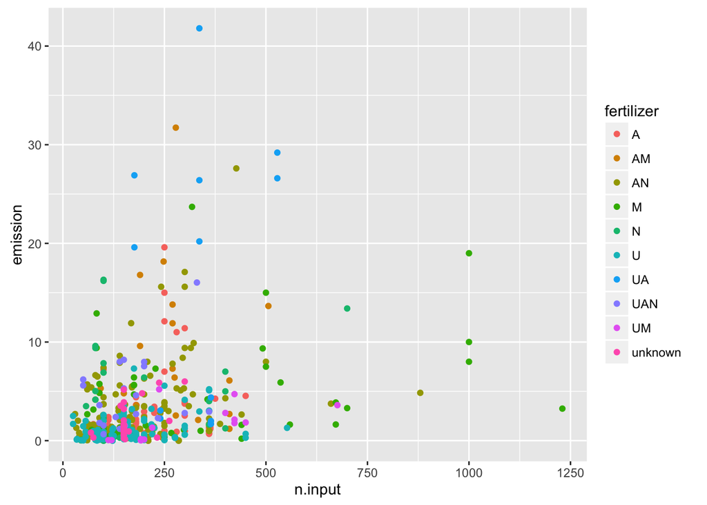

```r
qplot(n.input, emission, data=y, color =  fertilizer)
```

We will also need a function to link the sequential indices used in JAGS to the groups (fertilizer and site) in the data. Understanding how this is done is *critical* to your operational ability to do Bayesian analysis. I will work with you until you get it.

```r
group_from_index = function(group, group.index, output ){
  #group is a vector of group names or numbers
  #group.index is vector of sequential indices to group names or numbers.  It is a sequence of integers 1 to length(group)
  #output is a matrix or dataframe of output with number of rows = length(group). Each row contains statistics, etc for each group.
  a = unique(as.vector(group))
  b = unique(group.index)
  group.key=as.data.frame(t(rbind(a,b))) #columns containing indices paired with group name or number
  names(group.key)= c(names(as.data.frame(group)), names(as.data.frame(group.index)))
  link.column.name = names(group.key)[2] #name of column for merging output data with groups
  output2 = cbind(seq(1,nrow(output)),output) #give the output data sequential index the same as
  colnames(output2)[1]=link.column.name
  group.data=as.data.frame(merge(group.key, output2, by = link.column.name )) #merge the output with the groups
  return(group.data)
}
```

#### IV. Pooled model

Your first task is to write a simple, “pooled” model where you gloss over differences in sites and fertilizer types and lump everything into a set of x & y pairs using the R template provided `NO_2_models_all_data_template.R`. It is imperative that you study the data statement and match the variable names in your JAGS code to the left hand side of the = in the data list. Call the intercept `alpha`, the slope `beta` and use `sigma` to name the standard deviation in the likelihood.

```r
#very important to study this:
data = list(
  y.emission = log(y$emission),
  y.n.input = log(y$n.input)-mean(log(y$n.input)) #center the data to speed convergence and aid in interpretation.

)
  inits = list(
  list(
    alpha = 0,
    beta = .5,
    sigma = 50
  ),
  list(
    alpha = 1,
    beta = 1.5,
    sigma = 10
  )
)
```

Write the code for the model.

```r
####Pooled model
{
sink("PooledJAGS.R")
cat("
model{
#priors
alpha ~ dnorm(0,.0001)
beta ~ dnorm(0,.0001)
sigma ~ dunif(0,100)
tau.reg <- 1/sigma^2
#likelihood
 for(i in 1:length(y.emission)){
    mu[i] <- alpha + beta * y.n.input[i]
    y.emission[i] ~ dnorm(mu[i], tau.reg)
 }

}

",fill=TRUE)
sink()
}
```

Compile the model and take a look at it:

```r
  n.adapt=3000
  n.update=5000
  n.iter= 5000
jm.pooled = jags.model(file="PooledJAGS.R", data=data, n.adapt = n.adapt, inits=inits, n.chains=length(inits))
```

```
##    Graph Size: 1408
##
```

Now execute the MCMC:

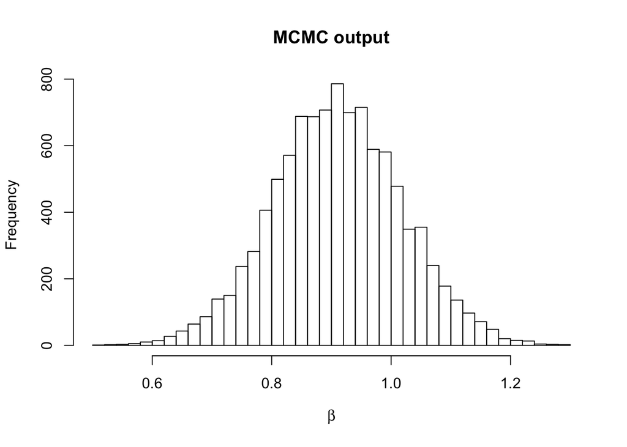

```r
update(jm.pooled, n.iter = n.update)
zc.pooled = coda.samples(jm.pooled, variable.names = c("alpha", "beta", "sigma"), n.iter=n.iter)
zj.pooled = jags.samples(jm.pooled, variable.names = c("alpha", "beta", "sigma"), n.iter=n.iter)
hist(zj.pooled$beta, xlab = expression(beta), breaks=50, main = "MCMC output")
```

```r
summary(zc.pooled)
```

```
##
## Iterations = 8001:13000
## Thinning interval = 1
## Number of chains = 2
## Sample size per chain = 5000
##
## 1. Empirical mean and standard deviation for each variable,
##    plus standard error of the mean:
##
##          Mean      SD  Naive SE Time-series SE
## alpha 0.04314 0.06819 0.0006819      0.0006819
## beta  0.91101 0.10713 0.0010713      0.0010714
## sigma 1.62590 0.04852 0.0004852      0.0006212
##
## 2. Quantiles for each variable:
##
##           2.5%       25%     50%     75%  97.5%
## alpha -0.09018 -0.003656 0.04265 0.08994 0.1774
## beta   0.69713  0.838499 0.91131 0.98390 1.1207
## sigma  1.53375  1.593398 1.62395 1.65805 1.7243
```

```r
gelman.diag(zc.pooled)
```

```
## Potential scale reduction factors:
##
##       Point est. Upper C.I.
## alpha          1          1
## beta           1          1
## sigma          1          1
##
## Multivariate psrf
##
## 1
```

#### IV. Intercepts for each site

Now you will implement the model that allows intercept to vary by group, where each intercept is drawn from a common distribution. Again, I use the template provided. Here are the preliminaries to set up the model:

```r
data = list(
  y.emission = log(y$emission),
  y.n.input = log(y$n.input) - mean(log(y$n.input)), #center the data to speed convergence and aid in interpretation. Can recover 0 intercept if needed.
  y.group = y$group.index,  #use j to index groups
  y.n.sites = length(unique(y$group))
)

inits = list(
  list(
    alpha = rep(0,y.n.sites),
    beta = .5,
    sigma = 50,
    mu.alpha= 0,
    sigma.alpha = 10
  ),
  list(
    alpha = rep(1,y.n.sites),
    beta = 1.5,
    sigma = 10,
    mu.alpha= -2,
    sigma.alpha = 20
  )
)
```

Write the model code. Note that you may not need to use the sink strcuture if you have JAGS code in a separate file.

```r
{ #note this opening { and the closing } are needed by R markdown but not by R
####Hierarchical model, site level intercept, no site covariate
sink("Hier_1")
cat("
    model{
    ##hyperpriors
    mu.alpha ~ dnorm(0,.00001)
    sigma.alpha ~ dunif(0,200) #notated varsigma in model documentation
    tau.alpha <- 1/sigma.alpha^2
    sigma ~ dunif(0,100)
    tau.reg <- 1/sigma^2
    ###priors
    for(j in 1:y.n.sites){
        alpha[j] ~ dnorm(mu.alpha,tau.alpha)
      }
    beta ~ dnorm(0,.0001)
    ####
    #likelihood
    for(i in 1:length(y.emission)){
        mu[i] <- alpha[y.group[i]] + beta * y.n.input[i]
        y.emission[i] ~ dnorm(mu[i], tau.reg)
    }

    }

    ",fill=TRUE)
sink()
}
```

Compile the model and get coda output. Test for convergence.

```r
n.update=50000
n.iter=25000

jm.hier1 = jags.model("Hier_1", data=data, n.adapt = 3000, inits=inits, n.chains=length(inits))
```

```
##    Graph Size: 2236
##
```

```r
update(jm.hier1, n.iter = n.update)
#You would wat to include alphas in check for convergnce but I eliminated them here to make output more compact.
zc.hier1 = coda.samples(jm.hier1, variable.names = c("sigma","beta", "mu.alpha", "sigma.alpha"), n.iter=n.iter)

summary(zc.hier1)
```

```
##
## Iterations = 53001:78000
## Thinning interval = 1
## Number of chains = 2
## Sample size per chain = 25000
##
## 1. Empirical mean and standard deviation for each variable,
##    plus standard error of the mean:
##
##               Mean      SD  Naive SE Time-series SE
## beta        0.8752 0.09384 0.0004197      0.0007075
## mu.alpha    0.1801 0.12987 0.0005808      0.0006971
## sigma       1.0271 0.03365 0.0001505      0.0002222
## sigma.alpha 1.2112 0.09925 0.0004438      0.0007317
##
## 2. Quantiles for each variable:
##
##                 2.5%     25%   50%    75%  97.5%
## beta         0.69129 0.81195 0.875 0.9385 1.0594
## mu.alpha    -0.07405 0.09199 0.180 0.2670 0.4359
## sigma        0.96435 1.00375 1.026 1.0491 1.0969
## sigma.alpha  1.03185 1.14186 1.206 1.2747 1.4191
```

```r
gelman.diag(zc.hier1)
```

```
## Potential scale reduction factors:
##
##             Point est. Upper C.I.
## beta                 1          1
## mu.alpha             1          1
## sigma                1          1
## sigma.alpha          1          1
##
## Multivariate psrf
##
## 1
```

#### V. Intercepts vary with carbon level in site soils and slopes vary with fertilizer type

Modify your model to include a co variate at the site level, soil carbon content and allow slopes to vary with fertilizer type as developed in the model writing problem #4.

Set up data and initial conditions:

```r
#######Hierarchical model, site level intercept predicted from carbon concentration covariate and slope varying with fertilizer type.

w=read.csv("Site_level_carbon_data for exercise.csv")
w$mean=w$mean/100  #transform % to proportion
data = list(
  y.emission = log(y$emission),
  y.n.input = log(y$n.input)-mean(log(y$n.input)), #center the data to speed convergence and aid in interpretation
  y.group=  y$group.index,
  y.fert = y$fert.index,
  y.n.sites = length(unique(y$group)),
  y.n.fert = length(unique(y$fertilizer)),
  w = log(w$mean/(1-w$mean))   #logit of w$mean
)
y.n.sites = length(unique(y$group))
y.n.fert = length(unique(y$fertilizer))
inits = list(
  list(
    alpha = rep(0,y.n.sites),
    beta = rep(.5,y.n.fert),
    sigma = 50,
    sigma.alpha = 10,
    kappa = .5
  ),
  list(
    alpha = rep(-.2,y.n.sites),
    beta = rep(1.5, y.n.fert),
    sigma = 10,
    sigma.alpha = 20,
    eta = .2,
    kappa = 5
  )
)
```

Write the model:

```r
{
sink("Hier_2")
cat("
    model{
    #priors for within site model######
    sigma ~ dunif(0,200)
    tau.reg <- 1/sigma^2

    #priors for intercept model#######
    kappa ~ dnorm(0,.00001)
    eta ~ dnorm(0, .000001)
    sigma.alpha ~ dunif(0,200)
    tau.alpha <- 1/sigma.alpha^2
    #hyper priors for slope model
    mu.beta ~ dnorm(0,.00001)
    sigma.beta ~ dunif(0,200)
    tau.beta <- 1/sigma.beta


    #likelihood for data, note that data are on log scale in data statement on R side
    for(i in 1:length(y.emission)){
      mu[i] <- alpha[y.group[i]] + beta[y.fert[i]] * y.n.input[i]
      y.emission[i] ~ dnorm(mu[i], tau.reg)
    }
    # carbon model for intercept
  for(j in 1:y.n.sites){
     #use normal because data are centered
      mu.alpha[j] <- kappa + eta *w[j]
      alpha[j] ~ dnorm(mu.alpha[j],tau.alpha)
  }
  #Allow slope to vary by fertilizer type
  for(k in 1:y.n.fert){
    beta[k] ~ dnorm(mu.beta, tau.beta)
  }
 } #end of model

    ",fill=TRUE)
sink()

}
```

Compile model and get some output:

```r
n.update=50000
n.iter=25000

jm.hier2 = jags.model("Hier_2", data=data, n.adapt = 3000, inits=inits, n.chains=length(inits))
```

```
##    Graph Size: 3220
##
```

```r
jm.hier2
```

```
## JAGS model:
##
##
##     model{
##     #priors for within site model######
##     sigma ~ dunif(0,200)
##     tau.reg <- 1/sigma^2
##
##     #priors for intercept model#######
##     kappa ~ dnorm(0,.00001)
##     eta ~ dnorm(0, .000001)
##     sigma.alpha ~ dunif(0,200)
##     tau.alpha <- 1/sigma.alpha^2
##     #hyper priors for slope model
##     mu.beta ~ dnorm(0,.00001)
##     sigma.beta ~ dunif(0,200)
##     tau.beta <- 1/sigma.beta
##
##
##     #likelihood for data, note that data are on log scale in data statement on R side
##     for(i in 1:length(y.emission)){
##       mu[i] <- alpha[y.group[i]] + beta[y.fert[i]] * y.n.input[i]
##       y.emission[i] ~ dnorm(mu[i], tau.reg)
##     }
##     # carbon model for intercept
##   for(j in 1:y.n.sites){
##      #use normal because data are centered
##       mu.alpha[j] <- kappa + eta *w[j]
##       alpha[j] ~ dnorm(mu.alpha[j],tau.alpha)
##   }
##   #Allow slope to vary by fertilizer type
##   for(k in 1:y.n.fert){
##     beta[k] ~ dnorm(mu.beta, tau.beta)
##   }
##  } #end of model
##
##
## Fully observed variables:
##  w y.emission y.fert y.group y.n.fert y.n.input y.n.sites
```

```r
update(jm.hier2, n.iter = n.update)
#You should run diagnostics on zc.hier coda object for intecepts and slopes but I eliminated them here to make output more compact
zc.hier2 = coda.samples(jm.hier2, variable.names = c("sigma","eta", "kappa", "mu.beta", "sigma.beta"), n.iter=n.iter)
zj.hier2 = jags.samples(jm.hier2, variable.names = c(variable.names = c("alpha", "beta", "sigma","eta", "kappa")), n.iter=n.iter)
gelman.diag(zc.hier2)
```

```
## Potential scale reduction factors:
##
##            Point est. Upper C.I.
## eta                 1          1
## kappa               1          1
## mu.beta             1          1
## sigma               1          1
## sigma.beta          1          1
##
## Multivariate psrf
##
## 1
```

```r
summary(zc.hier2)
```

```
##
## Iterations = 53001:78000
## Thinning interval = 1
## Number of chains = 2
## Sample size per chain = 25000
##
## 1. Empirical mean and standard deviation for each variable,
##    plus standard error of the mean:
##
##              Mean      SD  Naive SE Time-series SE
## eta        0.3176 0.15090 0.0006748      0.0048451
## kappa      1.4012 0.60029 0.0026846      0.0192185
## mu.beta    0.9533 0.22781 0.0010188      0.0016775
## sigma      1.0153 0.03376 0.0001510      0.0002267
## sigma.beta 0.3643 0.44449 0.0019878      0.0105176
##
## 2. Quantiles for each variable:
##
##               2.5%    25%    50%    75%  97.5%
## eta        0.02389 0.2168 0.3166 0.4177 0.6175
## kappa      0.23113 0.9982 1.3975 1.8003 2.5936
## mu.beta    0.51752 0.8164 0.9454 1.0828 1.4278
## sigma      0.95207 0.9920 1.0143 1.0373 1.0838
## sigma.beta 0.01738 0.1204 0.2408 0.4456 1.4368
```

```r
slopes=t(summary(zj.hier2$beta,quantile, c(.025,.5,.957))$stat) #transpose, the t( ), is important to make next function work


#slopes as function of fetilizer type
group.data=group_from_index(group=y$fertilizer,group.index=y$fert.index,output=slopes)

#table with medians and credible intervals for slopes by fertilizer type
group.data
```

```
##    group.index   group        2.5%       50%    95.7%
## 1            1       N -0.12727632 0.5702640 1.069614
## 2           10 unknown  0.34735604 1.1388936 2.061735
## 3            2       A  0.24751168 0.6810385 1.022856
## 4            3       M  0.52927105 0.8976803 1.216522
## 5            4      AN  0.48804000 0.7809310 1.028392
## 6            5      UM  0.85828628 1.6369005 2.405813
## 7            6       U  0.59745951 0.9984818 1.371925
## 8            7      UA  0.19305673 1.0083895 1.829538
## 9            8      AM  0.45819371 1.0615199 1.661009
## 10           9     UAN -0.04805377 0.7460151 1.327288
```

[figure not shown]

```r
#plot of medians and credible intervals for slopes by fertilizer type
names(group.data)[3:5]=c("lower", "median", "upper")
library(ggplot2)
ggplot( group.data, aes(x = group, y = median)) +    geom_bar(position = position_dodge(), stat="identity", fill="red")  +   geom_errorbar(aes(ymin=lower, ymax=upper)) +   ggtitle("Medians of slopes by fertilizer type with 95% credible intervals") + # plot title
  labs(x="Fertilizer", y=expression(beta)) +
  theme_bw() + # remove grey background (because Tufte said so)
  theme(panel.grid.major = element_blank()) # remove x and y major grid lines (because Tufte said so)
```

#### VI. Slope *and* intercepts vary by site

You may not make it all the way through this problem, but it is good to have a worked example because you are bound to encounter a problem very much like this one and the coding is not immediately intuitive. We now want to allow *both* slopes and intercepts to vary by site as described in the math exercise.

As usual, we set up data and initial values:

```r
data = list(
  y.emission = log(y$emission),
  y.n.input = log(y$n.input)-mean(log(y$n.input)), #center the data to speed convergence and aid in interpretation-- there is no such thing as soil with 0 carbon
  y.group=  y$group.index,
  y.fert = y$fert.index,
  y.n.sites = length(unique(y$group)),
  y.n.fert = length(unique(y$fertilizer))
)
y.n.sites = length(unique(y$group))
B = matrix(nrow=y.n.sites, ncol=2)
B[,1]=0
B[,2]=1.5
inits = list(
  list(
    B=B,
    sigma = 50,
    mu.alpha = 0,
    mu.beta = 1.5,
    sigma.alpha = 10,
    sigma.beta = 10,
    rho=-.5
  ),
  list(
    B=B*.5,
    sigma = 20,
    mu.alpha = -.2,
    mu.beta = .8,
    sigma.alpha = 50,
    sigma.beta = 50,
    rho=.5
  )
)
```

Now study the code below. There is a vector `B` that contains the mean of the intercept as its first element and the slope as the second element. The means of these elements are `mu.alpha` and `mu.beta` because JAGS will not allow a vector like `B[,1]` on the left hand side of ~. The slopes and intercepts in the likelihood are random variables drawn from a multivariate normal distribution with coprecision matrix `Tau.B`. We get `Tau.B` by taking the inverse of the covariance matrix, which we composed from `sigma.alpha` and `sigma.beta` and their covariances `sigma.alpha*sigam.beta*rho` where `rho` is the correlation between the slop and intercept.

```r
{
sink("Hier_3")
cat("
    model{
    #priors for within site model######
    sigma ~ dunif(0,200)
    tau.reg <- 1/sigma^2

    #likelihood for data, note that data are on log scale in data statement on R side
    for(i in 1:length(y.emission)){
      mu[i] <- alpha[y.group[i]] + beta[y.group[i]] * y.n.input[i]
      y.emission[i] ~ dnorm(mu[i], tau.reg)
    }
    # Model for group intercept and slope:
    for(j in 1:y.n.sites){
        alpha[j] <- B[j,1]  #group level intercept
        beta[j]  <- B[j,2]  #group level slope
        B[j,1:2] ~ dmnorm(B.hat[j,1:2], Tau.B)
        B.hat[j,1] <- mu.alpha  #required by JAGS syntax
        B.hat[j,2] <- mu.beta   #required by JAGS syntax
    }
    mu.alpha ~ dnorm(0,.0001)  #mean intercept
    mu.beta ~ dnorm(0, .0001)  #mean slope
    #Inverse of covariance matrix required by JAGS
    Tau.B[1:2,1:2] <- inverse(Sigma.B[1:2,1:2])
    #Elements of covariance matrix
    Sigma.B[1,1] <- sigma.alpha^2
    sigma.alpha ~ dunif(0,200)
    Sigma.B[2,2] <- sigma.beta^2
    sigma.beta ~ dunif(0,200)
    Sigma.B[1,2] <- rho*sigma.alpha*sigma.beta  # covariance is correlation coef. x product of variances
    Sigma.B[2,1] <- Sigma.B[1,2]
    rho ~ dunif(-1,1)
    } #end of model

    ",fill=TRUE)
sink()
}
```

Compile the model and get some output. Red bars give medians; black lines are 95% credible intervals

```r
n.update=50000
n.iter=10000

jm.hier3 = jags.model("Hier_3", data=data, n.adapt = 3000, inits=inits, n.chains=length(inits))
```

```
##    Graph Size: 2713
##
```

```r
update(jm.hier3, n.iter = n.update)
#You should run diagnostics on zc.hier coda object for intecepts and slopes but I eliminated them here to make output more compact
zc.hier3 = coda.samples(jm.hier3, variable.names = c('mu.alpha', "mu.beta", "rho"), n.iter=n.iter)
zj.hier3 = jags.samples(jm.hier3, variable.names = c("alpha", "beta", 'mu.alpha', "mu.beta", "rho"), n.iter=n.iter)
gelman.diag(zc.hier3)
```

```
## Potential scale reduction factors:
##
##          Point est. Upper C.I.
## mu.alpha       1.00       1.00
## mu.beta        1.01       1.01
## rho            1.00       1.01
##
## Multivariate psrf
##
## 1
```

```r
summary(zc.hier3)
```

```
##
## Iterations = 53001:63000
## Thinning interval = 1
## Number of chains = 2
## Sample size per chain = 10000
##
## 1. Empirical mean and standard deviation for each variable,
##    plus standard error of the mean:
##
##             Mean     SD  Naive SE Time-series SE
## mu.alpha  0.1844 0.1340 0.0009472       0.001708
## mu.beta   0.8659 0.1247 0.0008815       0.003217
## rho      -0.5488 0.1964 0.0013888       0.007686
##
## 2. Quantiles for each variable:
##
##              2.5%      25%     50%     75%   97.5%
## mu.alpha -0.07611  0.09558  0.1838  0.2737  0.4501
## mu.beta   0.61532  0.78388  0.8673  0.9496  1.1080
## rho      -0.87636 -0.69309 -0.5672 -0.4237 -0.1235
```

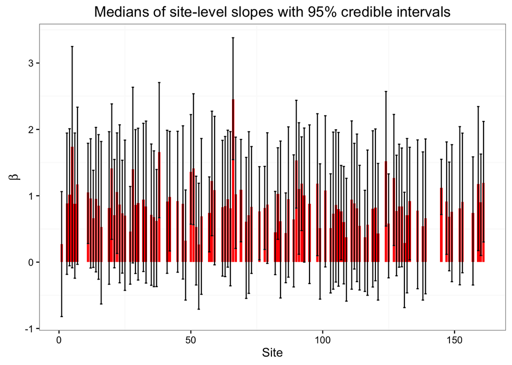

```r
#Make a vector to link sequential index (in ouput) to the group number.  Would work the same way if groups were character variables like names. t() is transpose. See group_from_index() function at top of file
slopes = t(summary(zj.hier3$beta, quantile, c(.025,.5,.975))$stat) #transpose is t() is important to make next function work
group.data=as.data.frame(group_from_index(group=y$group,group.index=y$group.index,output=slopes))
names(group.data)[3:5]=c("lower", "median", "upper")
library(ggplot2)
ggplot( group.data, aes(x = group, y = median)) +    geom_bar(position = position_dodge(), stat="identity", fill="red")  +   geom_errorbar(aes(ymin=lower, ymax=upper)) +   ggtitle("Medians of site-level slopes with 95% credible intervals") + # plot title
  labs(x="Site", y=expression(beta)) +
  theme_bw() + # remove grey background (because Tufte said so)
  theme(panel.grid.major = element_blank()) # remove x and y major grid lines (because Tufte said so)
```

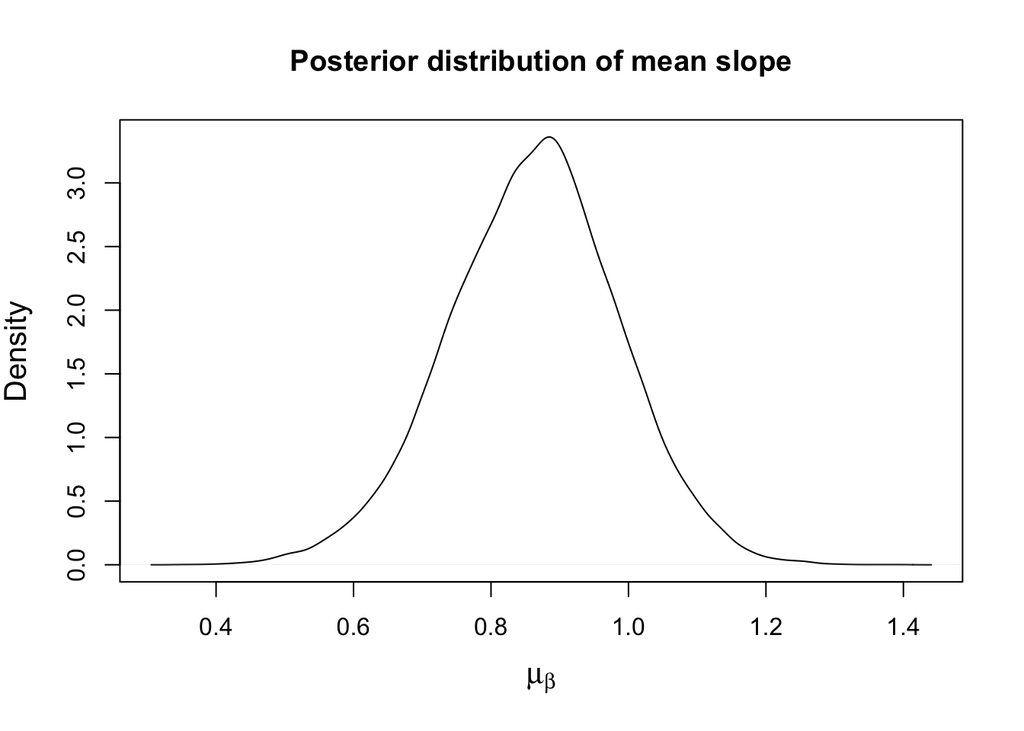

```r
plot(density(zj.hier3$mu.beta), xlab = expression(mu[beta]), main="Posterior distribution of mean slope", cex.lab=1.25)
```